# Sequence Visualization and Pattern Comparison

# Purpose

This tutorial covers two related tasks:

1. Visualizing raw sequences with `sequence_plot()`.
2. Comparing short sequence patterns with `sequence_compare()`.

The first task is descriptive. The second task is comparative and can include statistical testing.

# Sequence Plots

The `trajectories` data set contains engagement states for 138 learners across 15 time points.

```r
data(trajectories)
dim(trajectories)
```

```
#> [1] 138  15
```

```r
head(trajectories[, 1:8])
```

```
#>      1         2            3            4            5            6
#> [1,] "Active"  "Disengaged" "Disengaged" "Disengaged" "Active"     "Active"
#> [2,] "Average" "Average"    "Average"    "Average"    "Average"    "Average"
#> [3,] "Average" "Active"     "Active"     "Active"     "Active"     "Active"
#> [4,] "Active"  "Active"     "Active"     "Active"     "Active"     "Average"
#> [5,] "Active"  "Active"     "Active"     "Average"    "Active"     "Average"
#> [6,] "Average" "Average"    "Disengaged" "Average"    "Disengaged" "Disengaged"
#>      7         8
#> [1,] "Active"  "Active"
#> [2,] "Average" "Average"
#> [3,] "Active"  "Active"
#> [4,] "Average" "Active"
#> [5,] "Active"  "Active"
#> [6,] "Average" "Average"
```

```r
table(as.vector(trajectories), useNA = "ifany")
```

```
#>
#>     Active    Average Disengaged       <NA>
#>        703        813        354        200
```

## Heatmap

The default plot is a clustered heatmap. Rows are learners and columns are time points.

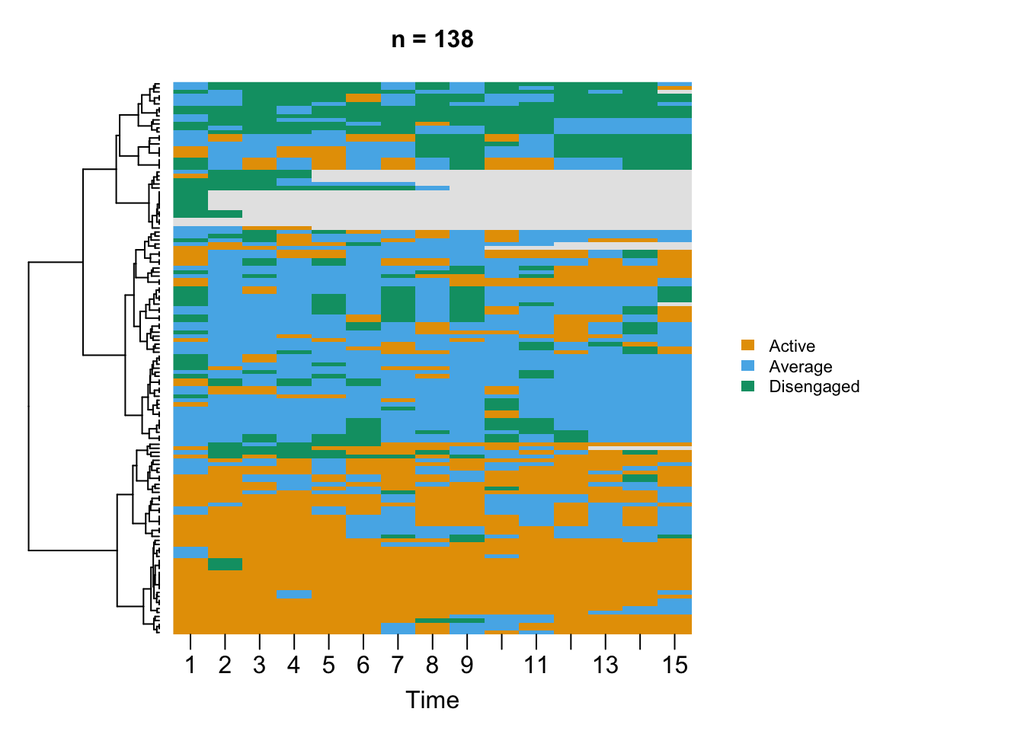

```r
sequence_plot(trajectories)
```

The default sorting uses sequence distance. Other sorting rules change the question the plot answers.

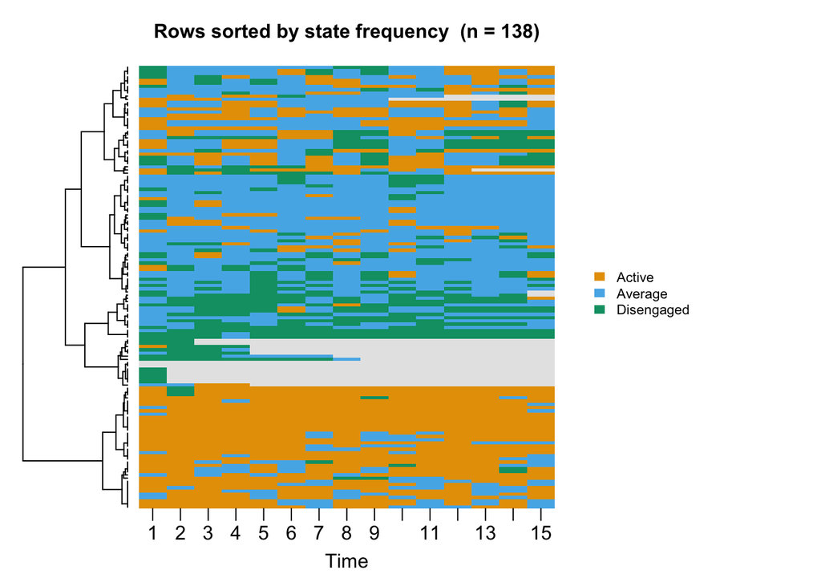

```r
sequence_plot(trajectories, sort = "frequency",
              main = "Rows sorted by state frequency")
```

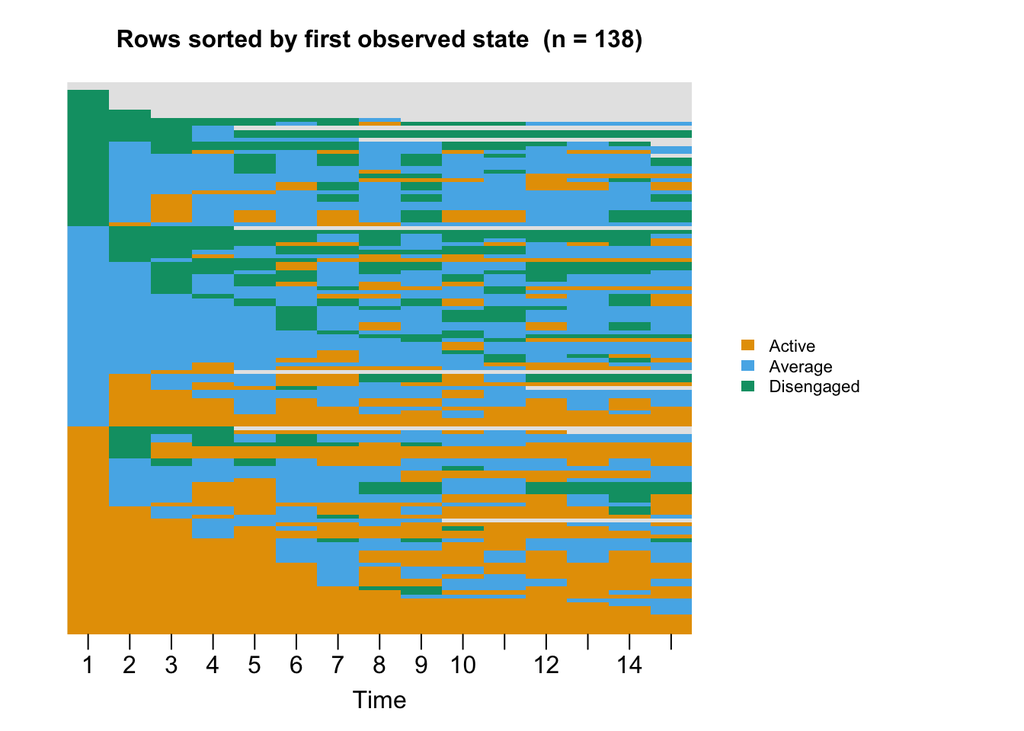

```r
sequence_plot(trajectories, sort = "start",
              main = "Rows sorted by first observed state")
```

Use `k` to show broad row groups from the dendrogram.

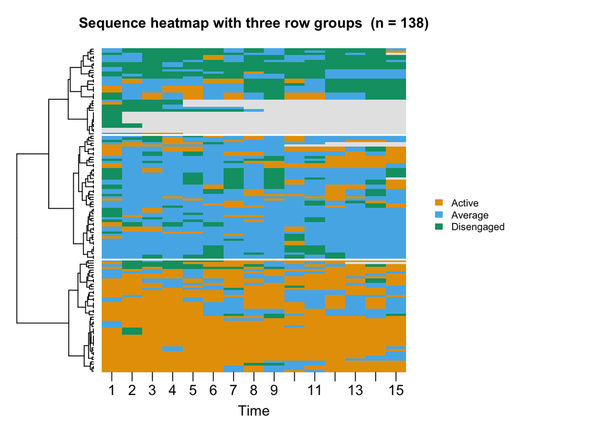

```r
sequence_plot(
  trajectories,
  k = 3,
  k_color = "white",
  k_line_width = 2,
  main = "Sequence heatmap with three row groups"
)
```

## Index Plot

The index plot removes the dendrogram and gives each sequence one row.

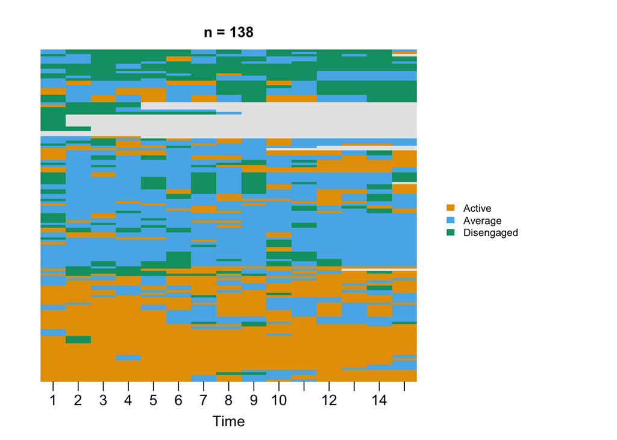

```r
sequence_plot(trajectories, type = "index")
```

If you pass a `net_clustering`, `sequence_plot()` facets by cluster.

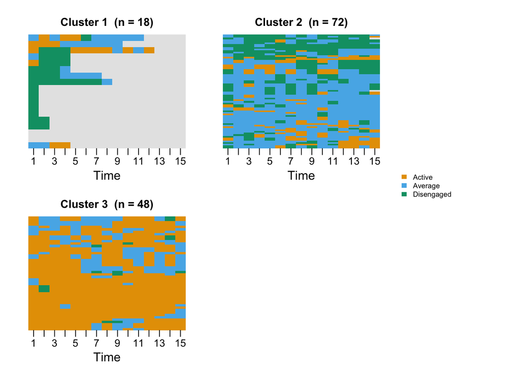

```r
cl <- build_clusters(
  as.data.frame(trajectories),
  k = 3,
  dissimilarity = "hamming",
  method = "ward.D2"
)

sequence_plot(cl, type = "index")
```

## Distribution Plot

The distribution view aggregates rows and shows how the state mix changes over time.

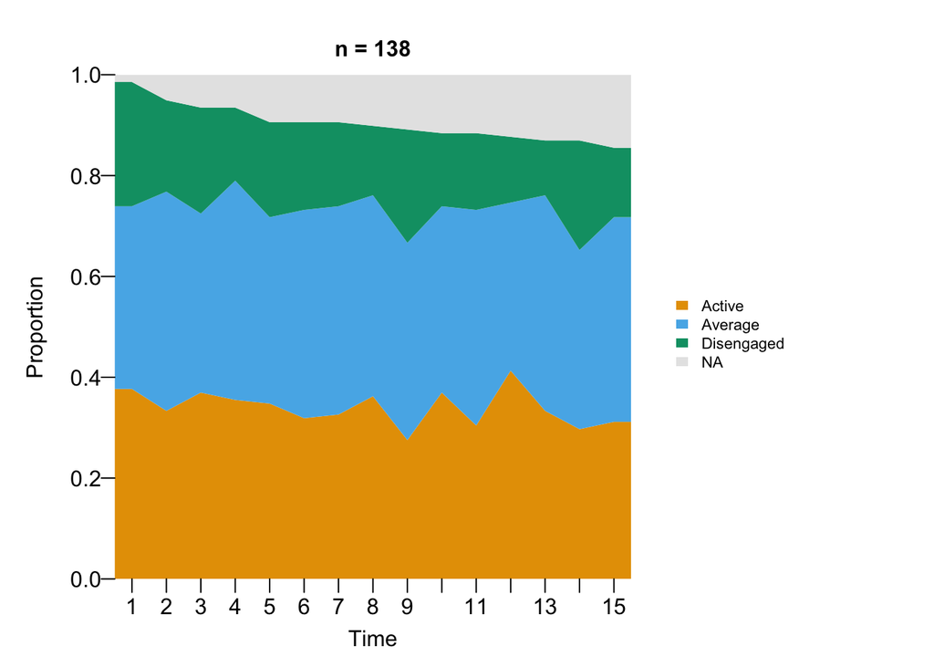

```r
sequence_plot(trajectories, type = "distribution")
```

Use bars and count scale when the number of observed learners matters.

[figure not shown]

```r
sequence_plot(
  trajectories,
  type = "distribution",
  geom = "bar",
  scale = "count"
)
```

The same view can be faceted by cluster.

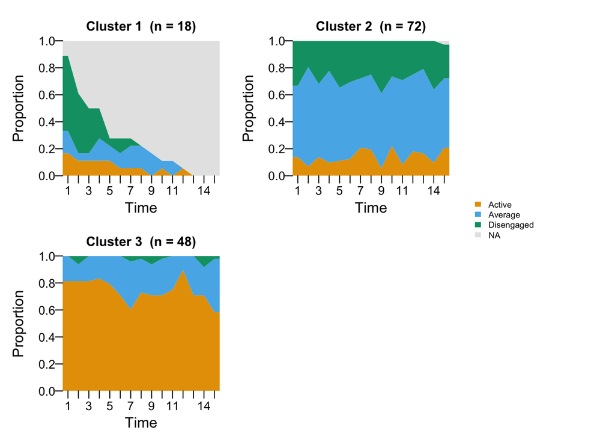

```r
sequence_plot(cl, type = "distribution")
```

## Custom Colors

Use named colors so the mapping stays clear.

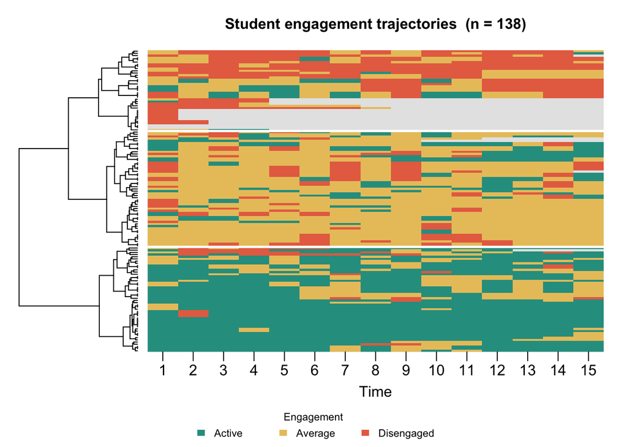

```r
engagement_colors <- c(
  Active = "#2A9D8F",
  Average = "#E9C46A",
  Disengaged = "#E76F51"
)

sequence_plot(
  trajectories,
  k = 3,
  state_colors = engagement_colors,
  legend = "bottom",
  legend_title = "Engagement",
  main = "Student engagement trajectories"
)
```

# Pattern Comparison

Sequence plots show the shape of the data. `sequence_compare()` tests whether short patterns are distributed differently across groups.

We compare early and late parts of each human-AI session. The split is within session, so the comparison asks whether patterns change over time inside the same sessions.

```r
data(human_long)
dat <- human_long[order(human_long$session_id, human_long$order_in_session), ]

dat$position <- ave(dat$order_in_session, dat$session_id, FUN = seq_along)
dat$n_events <- ave(dat$order_in_session, dat$session_id, FUN = length)
dat$half <- ifelse(dat$position <= dat$n_events / 2, "early", "late")

table(dat$half)
```

```
#>
#> early  late
#>  5287  5509
```

Build a grouped network using the broad `cluster` action labels.

```r
pattern_net <- build_network(
  dat,
  method = "relative",
  action = "cluster",
  actor = "session_id",
  time = "order_in_session",
  group = "half"
)

pattern_net
```

```
#> Group Networks (2 groups, group_col: half)
#>
#>   Group  Nodes  Edges  Weights
#>   early  3      9      [0.105, 0.637]
#>   late   3      9      [0.131, 0.575]
```

Now compare 3- to 5-step patterns.

```r
patterns <- sequence_compare(
  pattern_net,
  sub = 3:5,
  min_freq = 20,
  test = "chisq",
  adjust = "fdr"
)

patterns
```

```
#> Sequence Comparison  [118 patterns | 2 groups: early, late]
#>   Lengths: 3, 4, 5  |  min_freq: 20  |  chi-square  (fdr)
#>
#>                                                     pattern length freq_early
#>              Directive->Directive->Directive->Metacognitive      4        278
#>  Directive->Directive->Directive->Metacognitive->Evaluative      5         97
#>                             Directive->Directive->Directive      3       1052
#>                 Metacognitive->Metacognitive->Metacognitive      3         32
#>   Directive->Directive->Directive->Directive->Metacognitive      5        142
#>             Directive->Directive->Metacognitive->Evaluative      4        114
#>   Directive->Directive->Directive->Metacognitive->Directive      5        120
#>                            Evaluative->Directive->Directive      3        265
#>  freq_late prop_early   prop_late resid_early resid_late statistic      p_value
#>        149 0.06876082 0.035100118    6.929245  -6.929245  47.32807 7.085431e-10
#>         25 0.02645214 0.006488451    6.849638  -6.849638  45.67504 8.235836e-10
#>        842 0.23672367 0.180803092    6.568847  -6.568847  42.81109 2.371385e-09
#>        102 0.00720072 0.021902512   -5.820751   5.820751  32.87528 2.898813e-07
#>         71 0.03872375 0.018427200    5.303063  -5.303063  27.38985 3.924716e-06
#>         51 0.02819688 0.012014134    5.271906  -5.271906  26.96981 4.064280e-06
#>         63 0.03272430 0.016350895    4.605937  -4.605937  20.53065 9.892452e-05
#>        379 0.05963096 0.081382865   -4.045115   4.045115  16.03382 9.177615e-04
#>  [ reached 'max' / getOption("max.print") -- omitted 2 rows ]
#>   ... and 108 more patterns
```

```r
head(patterns$patterns, 12)
```

|  | pattern | length | freq_early | freq_late | prop_early | prop_late | resid_early | resid_late | statistic | p_value |
| --- | --- | --- | --- | --- | --- | --- | --- | --- | --- | --- |
| 1 | Directive->Directive->Directive->Metacognitive | 4 | 278 | 149 | 0.06876082 | 0.035100118 | 6.929245 | -6.929245 | 47.32807 | 7.085431e-10 |
| 2 | Directive->Directive->Directive->Metacognitive->Evaluative | 5 | 97 | 25 | 0.02645214 | 0.006488451 | 6.849638 | -6.849638 | 45.67504 | 8.235836e-10 |
| 3 | Directive->Directive->Directive | 3 | 1052 | 842 | 0.23672367 | 0.180803092 | 6.568847 | -6.568847 | 42.81109 | 2.371385e-09 |
| 4 | Metacognitive->Metacognitive->Metacognitive | 3 | 32 | 102 | 0.00720072 | 0.021902512 | -5.820751 | 5.820751 | 32.87528 | 2.898813e-07 |
| 5 | Directive->Directive->Directive->Directive->Metacognitive | 5 | 142 | 71 | 0.03872375 | 0.018427200 | 5.303063 | -5.303063 | 27.38985 | 3.924716e-06 |
| 6 | Directive->Directive->Metacognitive->Evaluative | 4 | 114 | 51 | 0.02819688 | 0.012014134 | 5.271906 | -5.271906 | 26.96981 | 4.064280e-06 |
| 7 | Directive->Directive->Directive->Metacognitive->Directive | 5 | 120 | 63 | 0.03272430 | 0.016350895 | 4.605937 | -4.605937 | 20.53065 | 9.892452e-05 |
| 8 | Evaluative->Directive->Directive | 3 | 265 | 379 | 0.05963096 | 0.081382865 | -4.045115 | 4.045115 | 16.03382 | 9.177615e-04 |
| 9 | Directive->Directive->Metacognitive | 3 | 327 | 249 | 0.07358236 | 0.053467898 | 3.939441 | -3.939441 | 15.18176 | 1.280192e-03 |
| 10 | Evaluative->Directive->Directive->Directive | 4 | 134 | 208 | 0.03314371 | 0.048998822 | -3.627419 | 3.627419 | 12.76045 | 4.177503e-03 |

[output cut: 2 more lines]

## Reading Residuals

For a given pattern, a positive residual in a group means the pattern appears more often than expected in that group. A negative residual means it appears less often than expected.

The pyramid plot works for two groups.

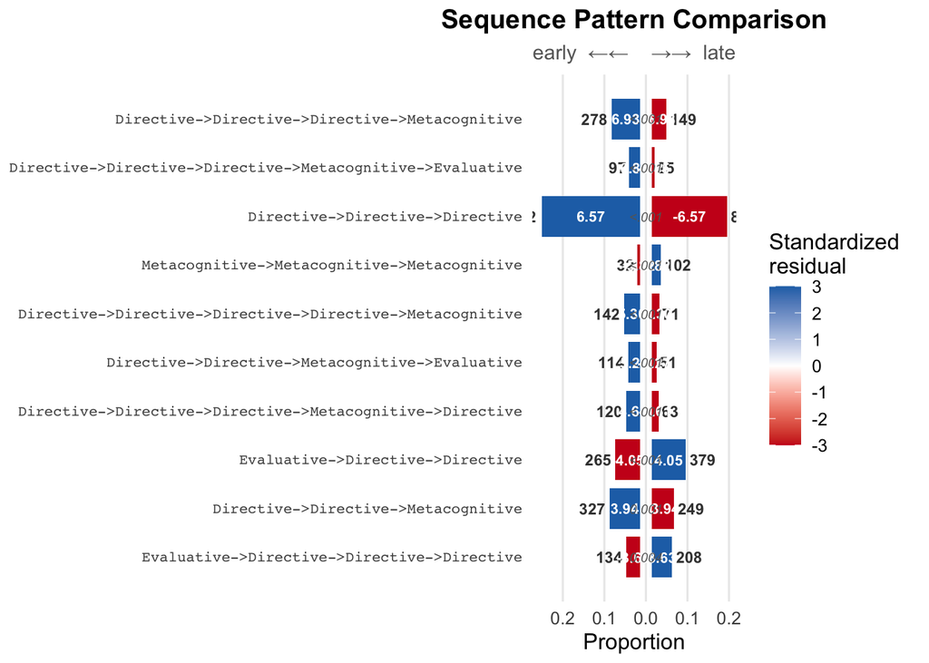

```r
plot(patterns, style = "pyramid", show_residuals = TRUE)
```

The heatmap is better when there are many groups or many patterns.

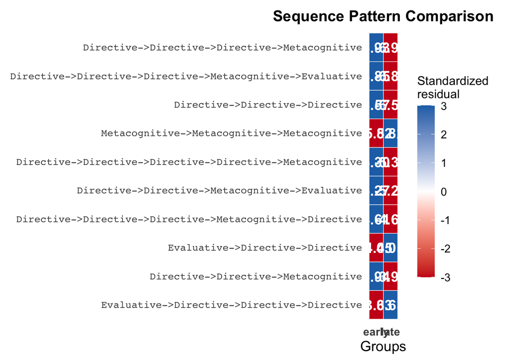

```r
plot(patterns, style = "heatmap")
```

Sort by frequency when the most common patterns are the focus.

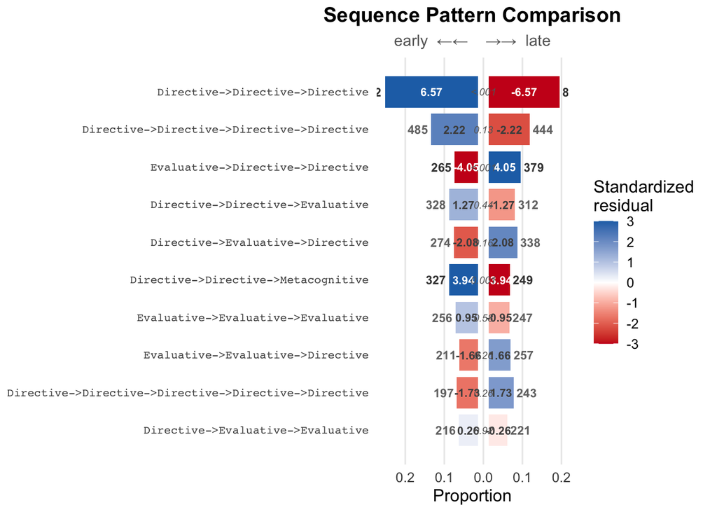

```r
plot(patterns, style = "pyramid", sort = "frequency",
     show_residuals = TRUE)
```

# Test Choice

The plot is only a summary. Always inspect `patterns$patterns` before making a substantive claim.